# Chapter 8

## 7. Note that if we don’t use argument names, we can obtain the same plot by making sure we enter the variable names in the right order like this:

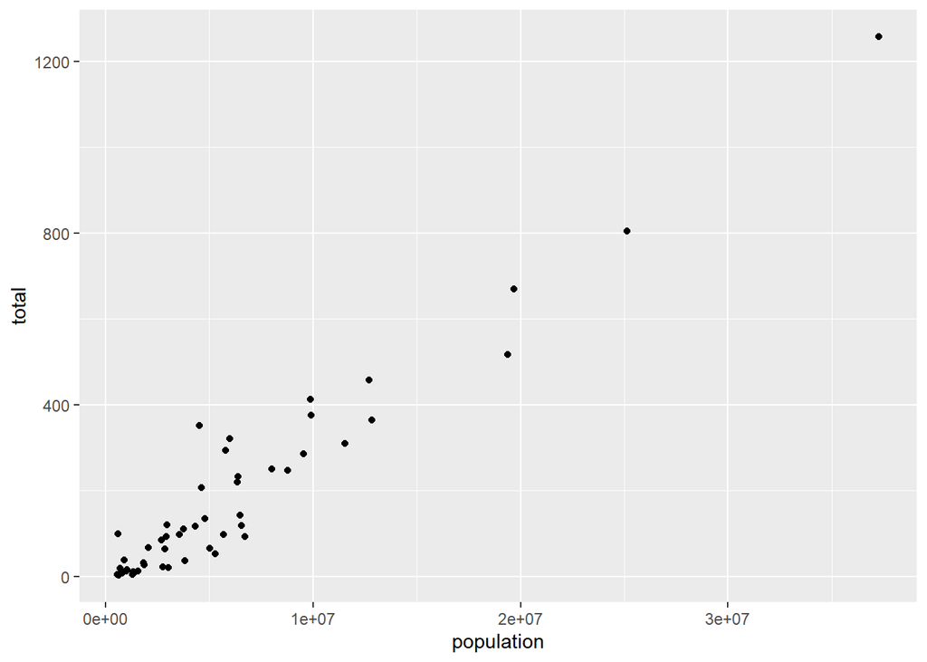

```r
murders |> ggplot(aes(population, total)) +
  geom_point()
```

## Remake the plot but now with total in the x-axis and population in the y-axis.

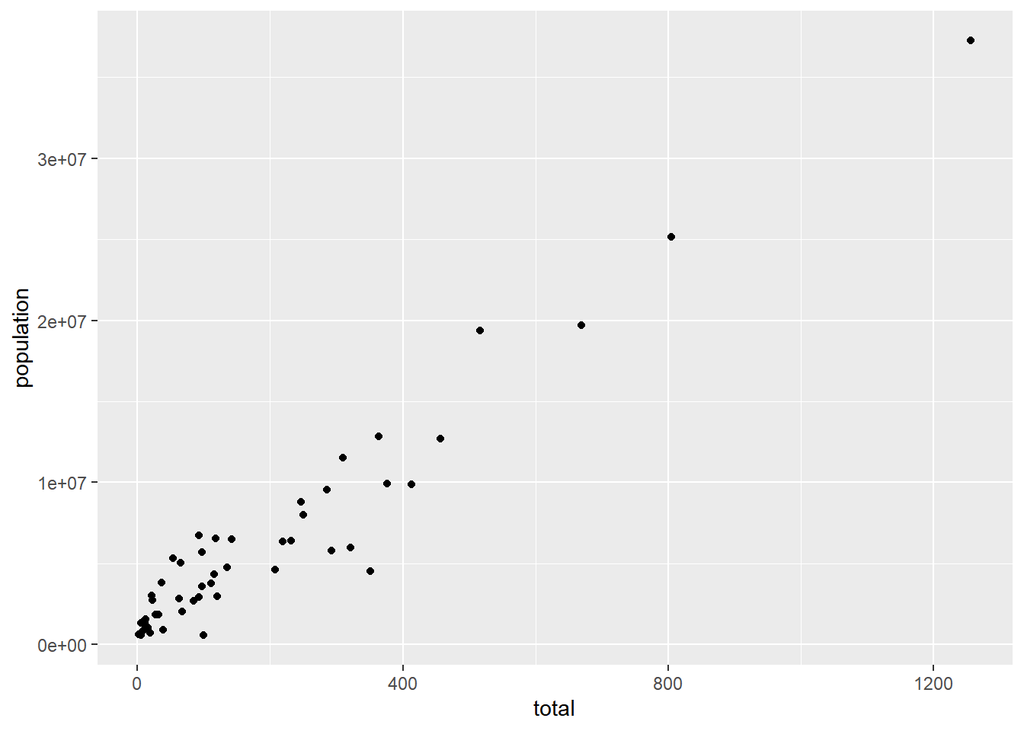

```r
murders |> ggplot(aes(total, population)) +
  geom_point()
```

## 8. If instead of points we want to add text, we can use the geom_text() or geom_label() geometries. The following code

```r
# murders |> ggplot(aes(population, total)) + geom_label()
```

## will give us the error message: Error: geom_label requires the following missing aesthetics: label

## Why is this?

### a. We need to map a character to each point through the label argument in aes.

### b. We need to let geom_label know what character to use in the plot.

### c. The geom_label geometry does not require x-axis and y-axis values.

### d. geom_label is not a ggplot2 command.

```r
# answer: a
```

## 9. Rewrite the code above to use abbreviation as the label through aes

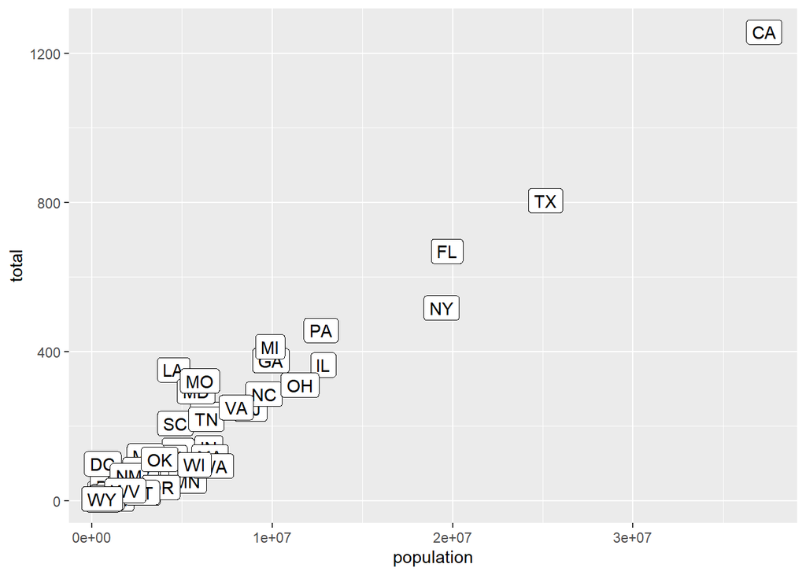

```r
murders |> ggplot(aes(population, total)) +
  geom_label(aes(population, total, label= abb))
```

## 10. Change the color of the labels to blue. How will we do this?

### a. Adding a column called blue to murders.

### b. Because each label needs a different color we map the colors through aes.

### c. Use the color argument in ggplot.

### d. Because we want all colors to be blue, we do not need to map colors, just use the color argument in geom_label.

```r
# answer: d
```

## 11. Rewrite the code above to make the labels blue.

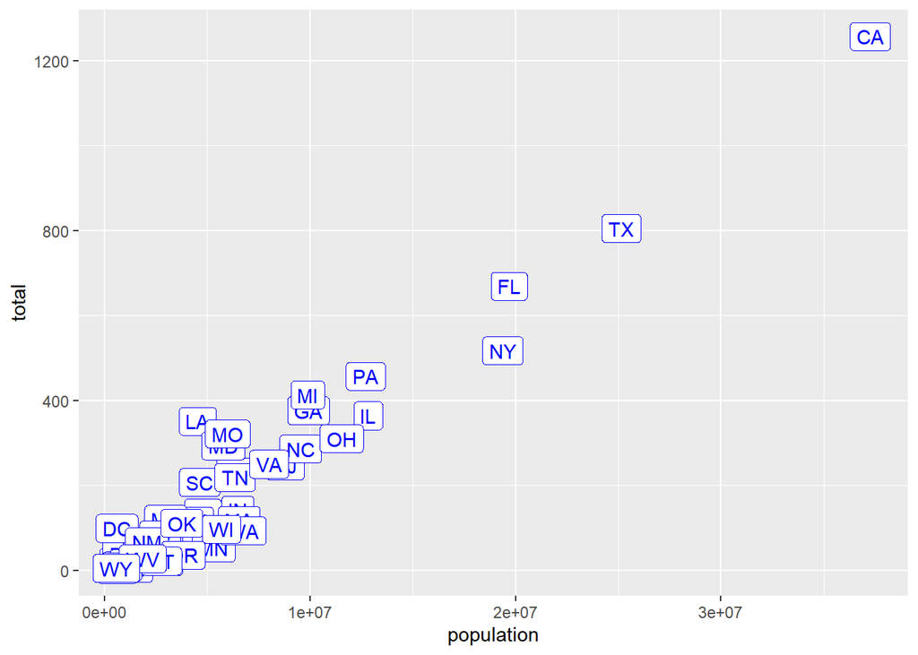

```r
murders |> ggplot(aes(population, total)) +
  geom_label(aes(population, total, label= abb), color="blue")
```

## 12. Now suppose we want to use color to represent the different regions. In this case which of the following is most appropriate:

### a. Adding a column called color to murders with the color we want to use.

### b. Because each label needs a different color we map the colors through the color argument of aes .

### c. Use the color argument in ggplot.

### d. Because we want all colors to be blue, we do not need to map colors, just use the color argument in geom_label.

```r
# answer: b
```

## 13. Rewrite the code above to make the labels’ color be determined by the state’s region.

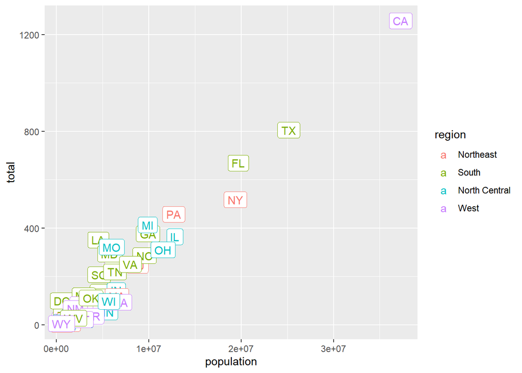

```r
murders |> ggplot(aes(population, total)) +
  geom_label(aes(population, total, label= abb, col= region))
```

## 14. Now we are going to change the x-axis to a log scale to account for the fact the distribution of population is skewed. Let’s start by defining an object p holding the plot we have made up to now

```r
p <- murders |>
  ggplot(aes(population, total, label = abb, color = region)) +
  geom_label()
```

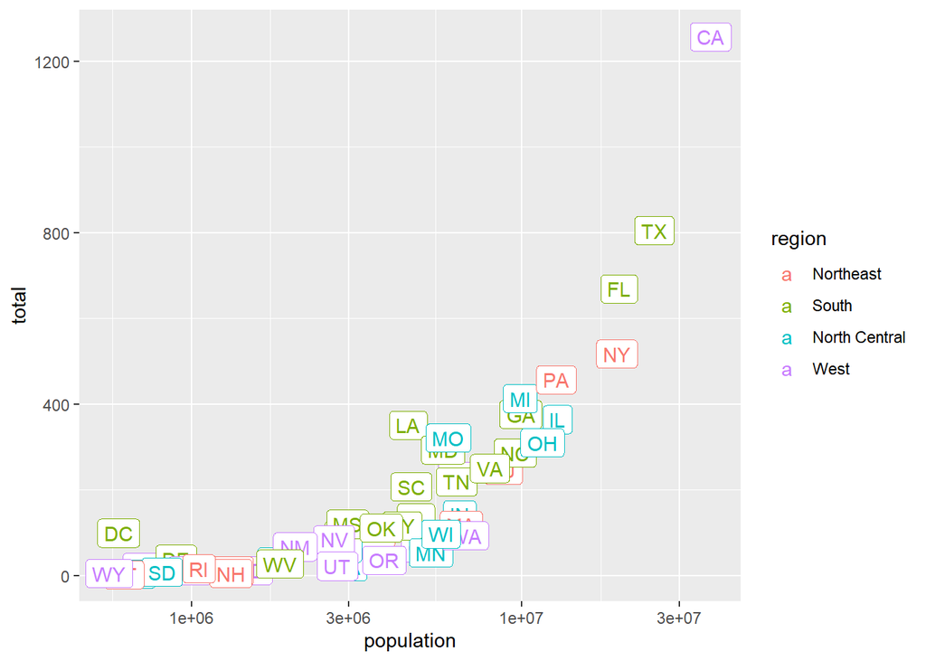

```r
p <- murders |>
  ggplot(aes(population, total, label = abb, color = region)) +
  geom_label()+
  scale_x_log10()

p
```

## 15. Repeat the previous exercise but now change both axes to be in the log scale.

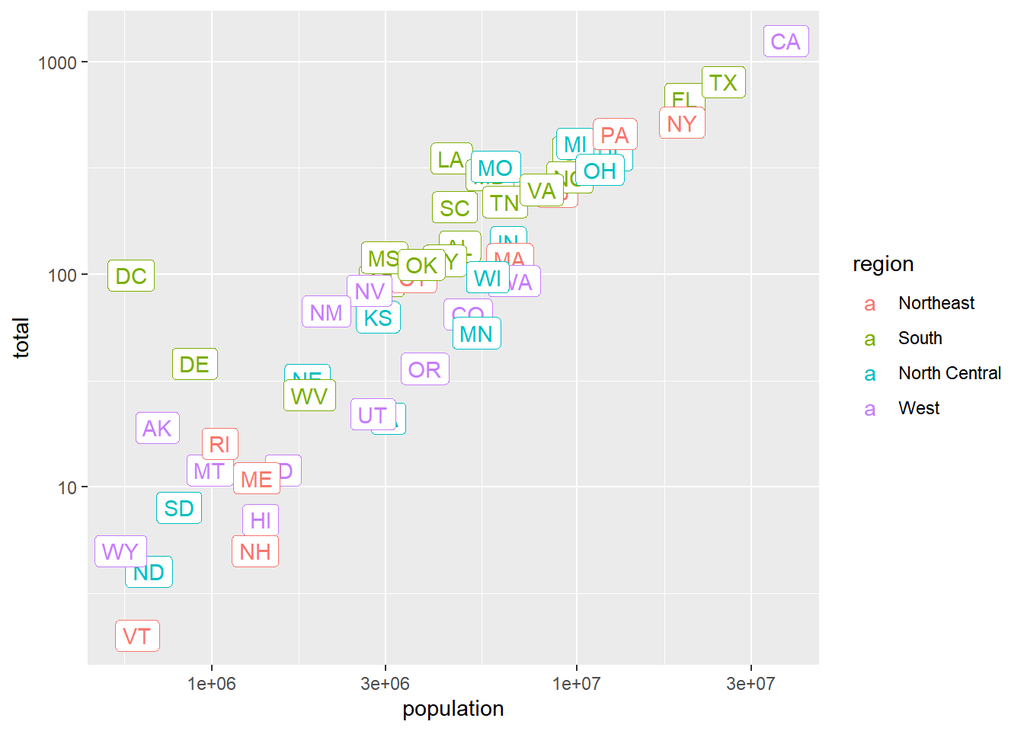

```r
p <- murders |>
  ggplot(aes(population, total, label = abb, color = region)) +
  geom_label()+
  scale_x_log10()+
  scale_y_log10()

p
```

## 16. Now edit the code above to add the title “Gun murder data” to the plot. Hint: use the ggtitle function.

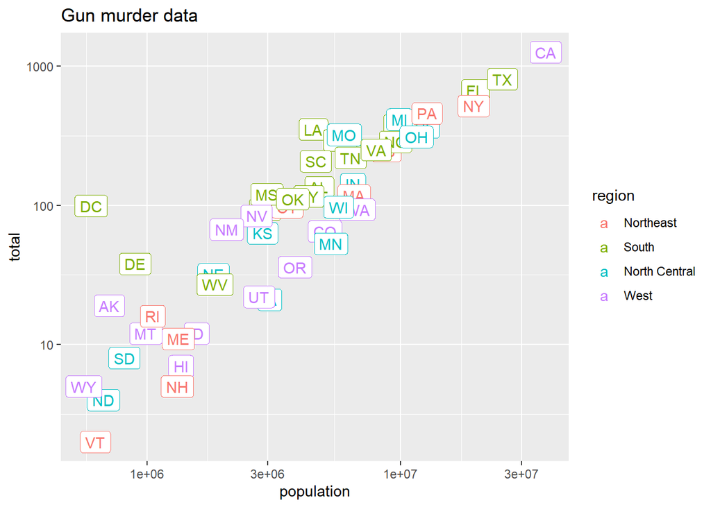

```r
p <- murders |>
  ggplot(aes(population, total, label = abb, color = region)) +
  geom_label()+
  scale_x_log10()+
  scale_y_log10()+
  ggtitle("Gun murder data")

p
```